# ICD Code Cuttoff Results

Author

Kody DeGolier

# ICD code instances and muscular dystrophy surveillance

## Tables

Case control table

| 0 | 1 |
| --- | --- |
| 860 | 320 |

Case control table by 5 unit bins

|  | 0 | 1 |
| --- | --- | --- |
| **0** | 577 | 141 |
| **5** | 93 | 59 |
| **10** | 47 | 29 |
| **15** | 27 | 24 |
| **20** | 12 | 14 |
| **25** | 9 | 12 |
| **30** | 10 | 7 |
| **35** | 8 | 8 |
| **40** | 77 | 26 |

Case control table by 10 unit bins

|  | 0 | 1 |
| --- | --- | --- |
| **0** | 670 | 200 |
| **10** | 74 | 53 |
| **20** | 21 | 26 |
| **30** | 18 | 15 |
| **40** | 77 | 26 |

## Histograms

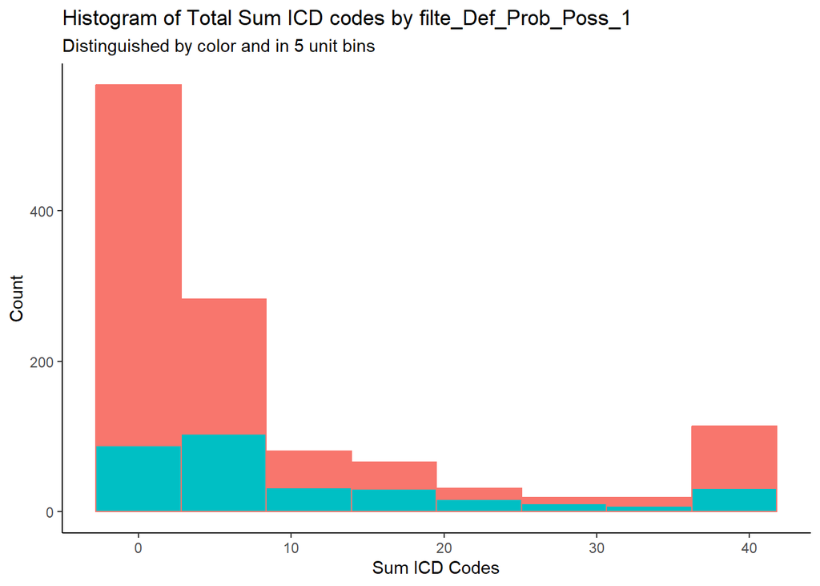

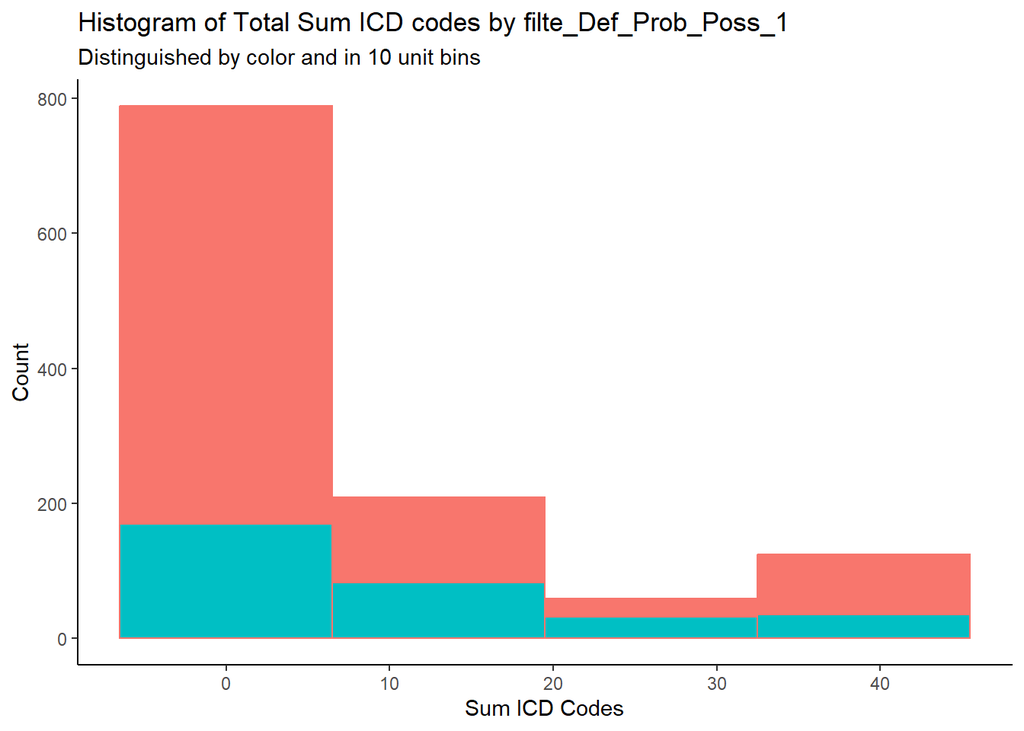

## Logistic Regression Models

### Logistic regression model with Total_Sum_ICD as a numeric variable and truncated at 40+ Sum ICD codes.

| **Characteristic** | **log(OR)**<sup>1</sup> | **95% CI**<sup>1</sup> | **p-value** |
| --- | --- | --- | --- |
| t_sum_ICD_trunc | 0.02 | 0.01, 0.03 | <0.001 |

<sup>1</sup> OR = Odds Ratio, CI = Confidence Interval

The odds of having muscular dystrophy increase by a multiplicative factor of e^(0.021814) = 1.022054 for each 1 unit increase in Total_Sum_ICD codes.

### ROC plot

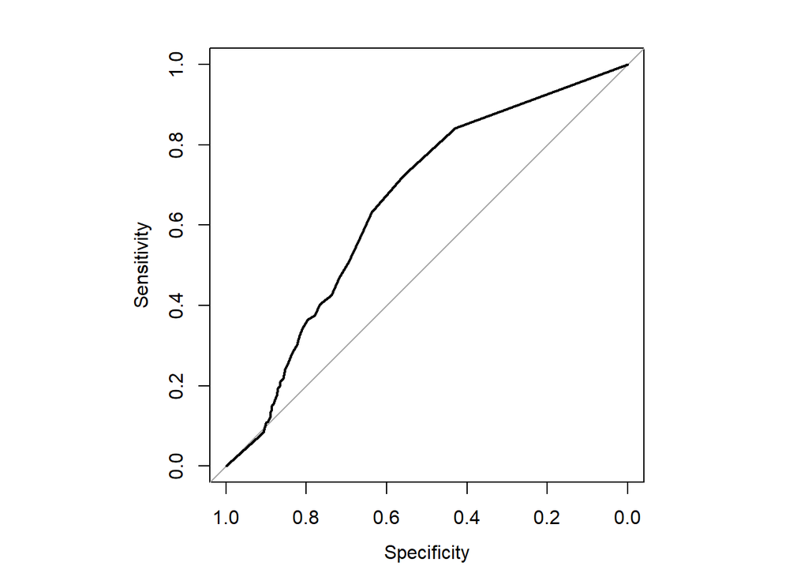

```
Call:
roc.default(response = V20_thresholded$filte_Def_Prob_Poss_1,     predictor = log_model_numeric$fitted.values, plot = TRUE)

Data: log_model_numeric$fitted.values in 860 controls (V20_thresholded$filte_Def_Prob_Poss_1 0) < 320 cases (V20_thresholded$filte_Def_Prob_Poss_1 1).
Area under the curve: 0.6554
```

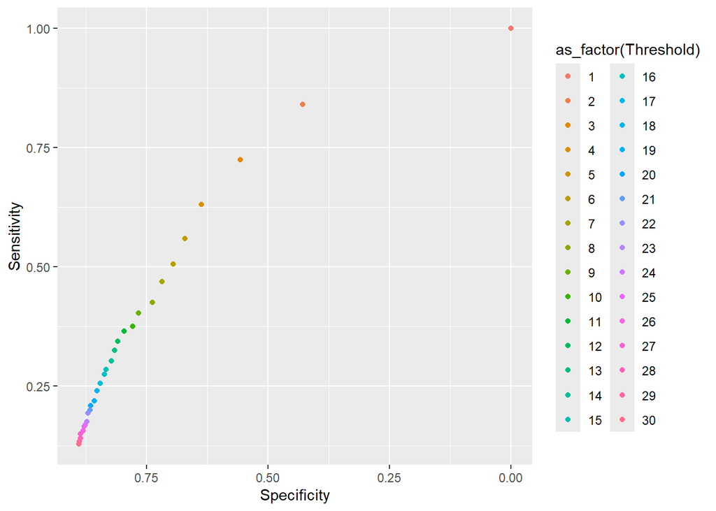

### Thresholds table for discussion

AUC for all of these thresholds is 0.6554.

Sensitivity is the proportion assigned as true positive divided by those that are actually positive.

Specificity denotes the proportion given a correct negative assignment out of those that are actually negative.

Accuracy is how close the measurements are to their true values. Sum_sens_spec is the sum of Sensitivity and Specificity.

MCC (Matthew’s correlation coefficient) is a gage to measure the difference between the predicted values and the actual values. Considers all four confusion matrix categories (true positives, false negatives, true negatives, and false positives). Norm_MCC is the MCC normalized to a scale of 0 to 1.

Youden’s index combined sensitivity and specificity into a single measure and ranges from 0 to 1. A perfect test would be equal to 1.

| Threshold | Sensitivity | Specificity | Accuracy | Sum_sens_spec | MCC | norm_MCC | Youden |
| --- | --- | --- | --- | --- | --- | --- | --- |
| 2 | 0.840625 | 0.4290698 | 0.5406780 | 1.269695 | 0.25041786 | 0.6252089 | 0.23030523 |
| 3 | 0.725000 | 0.5569767 | 0.6025424 | 1.281977 | 0.25090871 | 0.6254544 | 0.23030523 |
| 4 | 0.631250 | 0.6372093 | 0.6355932 | 1.268459 | 0.24070438 | 0.6203522 | 0.23030523 |
| 5 | 0.559375 | 0.6709302 | 0.6406780 | 1.230305 | 0.20977069 | 0.6048853 | 0.23030523 |
| 6 | 0.506250 | 0.6953488 | 0.6440678 | 1.201599 | 0.18679636 | 0.5933982 | 0.15406977 |
| 7 | 0.468750 | 0.7186047 | 0.6508475 | 1.187355 | 0.17684083 | 0.5884204 | 0.15406977 |
| 8 | 0.425000 | 0.7383721 | 0.6533898 | 1.163372 | 0.15761826 | 0.5788091 | 0.15406977 |
| 9 | 0.403125 | 0.7662791 | 0.6677966 | 1.169404 | 0.16779601 | 0.5838980 | 0.15406977 |
| 10 | 0.375000 | 0.7790698 | 0.6694915 | 1.154070 | 0.15563281 | 0.5778164 | 0.15406977 |
| 11 | 0.365625 | 0.7965116 | 0.6796610 | 1.162137 | 0.16703499 | 0.5835175 | 0.11809593 |
| 12 | 0.343750 | 0.8093023 | 0.6830508 | 1.153052 | 0.16114794 | 0.5805740 | 0.11809593 |
| 13 | 0.325000 | 0.8162791 | 0.6830508 | 1.141279 | 0.15112282 | 0.5755614 | 0.11809593 |
| 14 | 0.303125 | 0.8232558 | 0.6822034 | 1.126381 | 0.13769902 | 0.5688495 | 0.11809593 |
| 15 | 0.284375 | 0.8337209 | 0.6847458 | 1.118096 | 0.13167570 | 0.5658379 | 0.11809593 |
| 16 | 0.275000 | 0.8372093 | 0.6847458 | 1.112209 | 0.12634765 | 0.5631738 | 0.07449128 |
| 17 | 0.256250 | 0.8453488 | 0.6855932 | 1.101599 | 0.11701191 | 0.5585060 | 0.07449128 |
| 18 | 0.240625 | 0.8523256 | 0.6864407 | 1.092951 | 0.10927890 | 0.5546395 | 0.07449128 |
| 19 | 0.218750 | 0.8581395 | 0.6847458 | 1.076890 | 0.09261095 | 0.5463055 | 0.07449128 |
| 20 | 0.209375 | 0.8651163 | 0.6872881 | 1.074491 | 0.09148640 | 0.5457432 | 0.07449128 |
| 21 | 0.200000 | 0.8662791 | 0.6855932 | 1.066279 | 0.08214045 | 0.5410702 | 0.04469477 |
| 22 | 0.193750 | 0.8709302 | 0.6872881 | 1.064680 | 0.08129391 | 0.5406470 | 0.04469477 |
| 23 | 0.175000 | 0.8732558 | 0.6838983 | 1.048256 | 0.06185843 | 0.5309292 | 0.04469477 |
| 24 | 0.168750 | 0.8767442 | 0.6847458 | 1.045494 | 0.05907722 | 0.5295386 | 0.04469477 |
| 25 | 0.165625 | 0.8790698 | 0.6855932 | 1.044695 | 0.05850504 | 0.5292525 | 0.04469477 |
| 26 | 0.156250 | 0.8813953 | 0.6847458 | 1.037645 | 0.04995940 | 0.5249797 | 0.01765988 |
| 27 | 0.150000 | 0.8860465 | 0.6864407 | 1.036047 | 0.04866881 | 0.5243344 | 0.01765988 |
| 28 | 0.140625 | 0.8860465 | 0.6838983 | 1.026672 | 0.03633410 | 0.5181671 | 0.01765988 |
| 29 | 0.134375 | 0.8883721 | 0.6838983 | 1.022747 | 0.03137020 | 0.5156851 | 0.01765988 |
| 30 | 0.128125 | 0.8895349 | 0.6830508 | 1.017660 | 0.02458625 | 0.5122931 | 0.01765988 |

### Logistic regression model with Total_Sum_ICD as a categorical variable with all of the bins.

*Baseline group are those with 0-5 ICD codes*

```r
log_model_binned <- glm(filte_Def_Prob_Poss_1 ~ as_factor(t_sum_ICD_bin_trunc), data = V20_thresholded, family = binomial)
# summary(log_model_binned)
tbl_regression(log_model_binned)
```

| **Characteristic** | **log(OR)**<sup>1</sup> | **95% CI**<sup>1</sup> | **p-value** |
| --- | --- | --- | --- |
| as_factor(t_sum_ICD_bin_trunc) |  |  |  |
| 0 | — | — |  |
| 5 | 0.95 | 0.58, 1.3 | <0.001 |
| 10 | 0.93 | 0.42, 1.4 | <0.001 |
| 15 | 1.3 | 0.71, 1.9 | <0.001 |
| 20 | 1.6 | 0.77, 2.4 | <0.001 |
| 25 | 1.7 | 0.82, 2.6 | <0.001 |
| 30 | 1.1 | 0.02, 2.0 | 0.036 |
| 35 | 1.4 | 0.39, 2.4 | 0.006 |
| 40 | 0.32 | -0.17, 0.79 | 0.2 |

<sup>1</sup> OR = Odds Ratio, CI = Confidence Interval

```r
# par(pty="s")
# roc(V20_thresholded$filte_Def_Prob_Poss_1, log_model_binned$fitted.values, plot=TRUE)
```

#### *Baseline group are those with 5-10 ICD codes*

| **Characteristic** | **log(OR)**<sup>1</sup> | **95% CI**<sup>1</sup> | **p-value** |
| --- | --- | --- | --- |
| t_sum_ICD_bin_trunc |  |  |  |
| 5 | — | — |  |
| 0 | -0.95 | -1.3, -0.58 | <0.001 |
| 10 | -0.03 | -0.60, 0.54 | >0.9 |
| 15 | 0.34 | -0.31, 0.98 | 0.3 |
| 20 | 0.61 | -0.23, 1.5 | 0.2 |
| 25 | 0.74 | -0.18, 1.7 | 0.12 |
| 30 | 0.10 | -0.96, 1.1 | 0.8 |
| 35 | 0.46 | -0.59, 1.5 | 0.4 |
| 40 | -0.63 | -1.2, -0.09 | 0.025 |

<sup>1</sup> OR = Odds Ratio, CI = Confidence Interval

#### *Baseline group are those with 10-15 ICD codes*

| **Characteristic** | **log(OR)**<sup>1</sup> | **95% CI**<sup>1</sup> | **p-value** |
| --- | --- | --- | --- |
| t_sum_ICD_bin_trunc |  |  |  |
| 10 | — | — |  |
| 0 | -0.93 | -1.4, -0.42 | <0.001 |
| 5 | 0.03 | -0.54, 0.60 | >0.9 |
| 15 | 0.37 | -0.35, 1.1 | 0.3 |
| 20 | 0.64 | -0.26, 1.6 | 0.2 |
| 25 | 0.77 | -0.20, 1.8 | 0.12 |
| 30 | 0.13 | -0.98, 1.2 | 0.8 |
| 35 | 0.48 | -0.61, 1.6 | 0.4 |
| 40 | -0.60 | -1.2, 0.04 | 0.066 |

<sup>1</sup> OR = Odds Ratio, CI = Confidence Interval

#### *Baseline group are those with 15-20 ICD codes*

| **Characteristic** | **log(OR)**<sup>1</sup> | **95% CI**<sup>1</sup> | **p-value** |
| --- | --- | --- | --- |
| t_sum_ICD_bin_trunc |  |  |  |
| 15 | — | — |  |
| 0 | -1.3 | -1.9, -0.71 | <0.001 |
| 5 | -0.34 | -0.98, 0.31 | 0.3 |
| 10 | -0.37 | -1.1, 0.35 | 0.3 |
| 20 | 0.27 | -0.67, 1.2 | 0.6 |
| 25 | 0.41 | -0.61, 1.5 | 0.4 |
| 30 | -0.24 | -1.4, 0.87 | 0.7 |
| 35 | 0.12 | -1.0, 1.3 | 0.8 |
| 40 | -0.97 | -1.7, -0.26 | 0.007 |

<sup>1</sup> OR = Odds Ratio, CI = Confidence Interval

#### *Baseline group are those with 0-9 ICD codes*

| **Characteristic** | **log(OR)**<sup>1</sup> | **95% CI**<sup>1</sup> | **p-value** |
| --- | --- | --- | --- |
| t_sum_ICD_bin_trunc |  |  |  |
| zero_to_9 | — | — |  |
| ten_to_19 | 0.88 | 0.49, 1.3 | <0.001 |
| twenty_to_29 | 1.4 | 0.83, 2.0 | <0.001 |
| thirty_to_39 | 1.0 | 0.31, 1.7 | 0.004 |
| fourty_plus | 0.12 | -0.36, 0.58 | 0.6 |

<sup>1</sup> OR = Odds Ratio, CI = Confidence Interval

#### *Baseline group are those with 10-19 ICD codes*

| **Characteristic** | **log(OR)**<sup>1</sup> | **95% CI**<sup>1</sup> | **p-value** |
| --- | --- | --- | --- |
| t_sum_ICD_bin_trunc |  |  |  |
| ten_to_19 | — | — |  |
| zero_to_9 | -0.88 | -1.3, -0.49 | <0.001 |
| twenty_to_29 | 0.55 | -0.12, 1.2 | 0.11 |
| thirty_to_39 | 0.15 | -0.63, 0.92 | 0.7 |
| fourty_plus | -0.75 | -1.3, -0.19 | 0.009 |

<sup>1</sup> OR = Odds Ratio, CI = Confidence Interval

#### *Baseline group are those with 0-14 ICD codes*

| **Characteristic** | **log(OR)**<sup>1</sup> | **95% CI**<sup>1</sup> | **p-value** |
| --- | --- | --- | --- |
| T_Sum_ICD_bin_TH |  |  |  |
| zero_to_14 | — | — |  |
| fifteen_to_29 | 1.2 | 0.76, 1.6 | <0.001 |
| thirty_plus | 0.30 | -0.10, 0.69 | 0.14 |

<sup>1</sup> OR = Odds Ratio, CI = Confidence Interval

#### *Baseline group are those with 15-29 ICD codes*

| **Characteristic** | **log(OR)**<sup>1</sup> | **95% CI**<sup>1</sup> | **p-value** |
| --- | --- | --- | --- |
| T_Sum_ICD_bin_TH |  |  |  |
| fifteen_to_29 | — | — |  |
| zero_to_14 | -1.2 | -1.6, -0.76 | <0.001 |
| thirty_plus | -0.88 | -1.4, -0.35 | 0.001 |

<sup>1</sup> OR = Odds Ratio, CI = Confidence Interval

#### *Baseline group are those with 0-19 ICD codes*

| **Characteristic** | **log(OR)**<sup>1</sup> | **95% CI**<sup>1</sup> | **p-value** |
| --- | --- | --- | --- |
| T_Sum_ICD_bin_TH |  |  |  |
| zero_to_19 | — | — |  |
| twenty_to_39 | 1.1 | 0.67, 1.6 | <0.001 |
| fourty_plus | -0.01 | -0.49, 0.45 | >0.9 |

<sup>1</sup> OR = Odds Ratio, CI = Confidence Interval

#### *Baseline group are those with 20-39 ICD codes*

| **Characteristic** | **log(OR)**<sup>1</sup> | **95% CI**<sup>1</sup> | **p-value** |
| --- | --- | --- | --- |
| T_Sum_ICD_bin_TH |  |  |  |
| twenty_to_39 | — | — |  |
| zero_to_19 | -1.1 | -1.6, -0.67 | <0.001 |
| fourty_plus | -1.1 | -1.8, -0.52 | <0.001 |

<sup>1</sup> OR = Odds Ratio, CI = Confidence Interval